# Assignment 3 : Data Visualization (incarceration)

Angela Lin

2/22/2022

### 1. Introduction

In this data visualization, I want to look at the differences in incarceration number by state, race, gender, and age. I choose to analyze the population in jail of different states and races. Also, I want to compare the difference in population in jail between males and females, teenagers and adults.

### 2. Summary Information

```
## $`race with highest total jail population`
## [1] "white"
##
## $` state with  the highest total jail population`
## [1] "CA"
##
## $`state with the current highest total jail population`
## [1] "CA"
##
## $`ratio of female in jail to male in jail in the most recent year`
## [1] 0.153
##
## $`state with the highest average ratio of total_jail_pop to total_pop in the most recent year`
## [1] "LA"
##
## $`ratio of juvenile in jail to adult in jail`
## [1] 0.011
```

### 3. Trends over time chart

This chart helps to demonstrate how the population in jail of different races develop over time. In the trends over time chart, I use points to represent the population in each year and lines in the chart to display the overall trend.

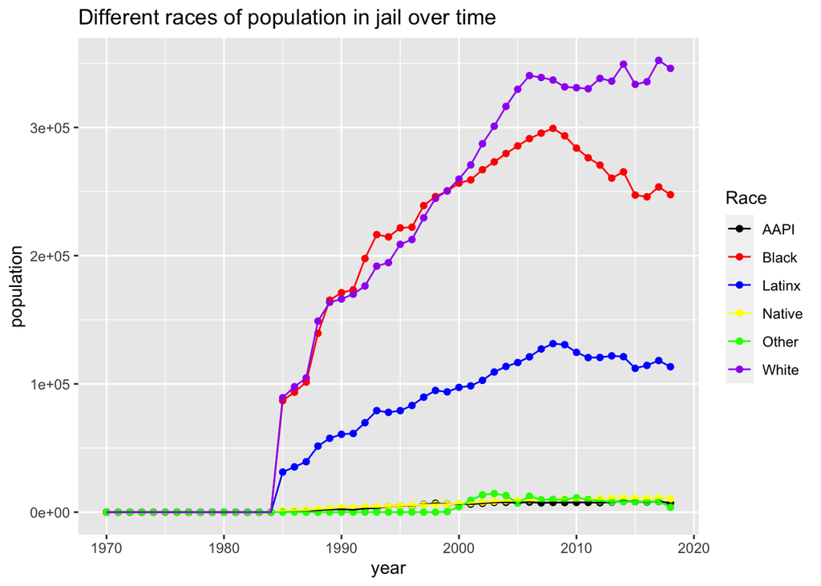

### 4. Variable comparison chart

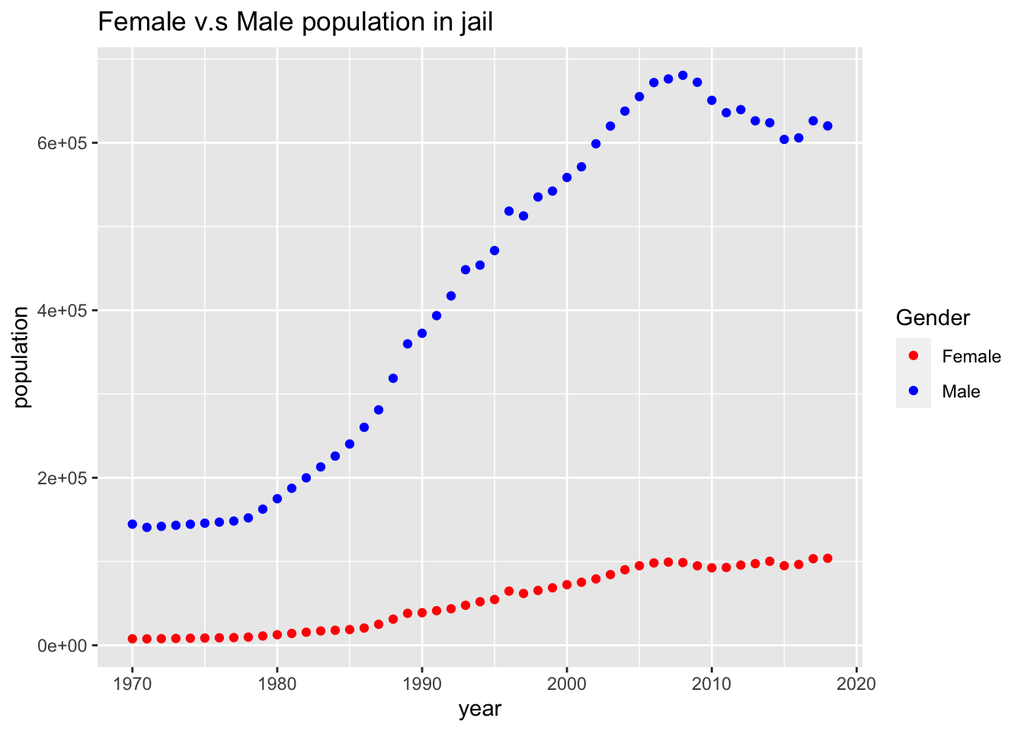

### 5. Map

This map shows the population in jail distributed in Washington counties in 2018. By clicking the pins, it shows the county’s name and its population in jail in 2018.

[interactive chart not shown]